# Risk Factor Analysis

## Outcome Variable

**Outcome Variable:** stunted

## Predictor Variables

**Intervention Variable:** meducyrs

**Adjustment Set:**

unadjusted

## Stratifying Variables

The analysis was stratified on these variable(s):

- agecat
- studyid

The following strata were considered:

- agecat: 12 months, studyid: ki0047075b-MAL-ED
- agecat: 12 months, studyid: ki1000108-CMC-V-BCS-2002
- agecat: 12 months, studyid: ki1000108-IRC
- agecat: 12 months, studyid: ki1000109-EE
- agecat: 12 months, studyid: ki1000304b-SAS-FoodSuppl
- agecat: 12 months, studyid: ki1017093-NIH-Birth
- agecat: 12 months, studyid: ki1017093b-PROVIDE
- agecat: 12 months, studyid: ki1017093c-NIH-Crypto
- agecat: 12 months, studyid: ki1066203-TanzaniaChild2
- agecat: 12 months, studyid: ki1112895-Guatemala BSC
- agecat: 12 months, studyid: ki1113344-GMS-Nepal
- agecat: 12 months, studyid: ki1126311-ZVITAMBO
- agecat: 12 months, studyid: ki1135781-COHORTS
- agecat: 12 months, studyid: ki1148112-LCNI-5
- agecat: 18 months, studyid: ki0047075b-MAL-ED
- agecat: 18 months, studyid: ki1000108-CMC-V-BCS-2002
- agecat: 18 months, studyid: ki1000108-IRC
- agecat: 18 months, studyid: ki1000109-EE
- agecat: 18 months, studyid: ki1000304b-SAS-FoodSuppl
- agecat: 18 months, studyid: ki1017093-NIH-Birth
- agecat: 18 months, studyid: ki1017093b-PROVIDE
- agecat: 18 months, studyid: ki1017093c-NIH-Crypto
- agecat: 18 months, studyid: ki1066203-TanzaniaChild2
- agecat: 18 months, studyid: ki1113344-GMS-Nepal
- agecat: 18 months, studyid: ki1126311-ZVITAMBO
- agecat: 18 months, studyid: ki1135781-COHORTS
- agecat: 18 months, studyid: ki1148112-LCNI-5
- agecat: 24 months, studyid: ki0047075b-MAL-ED
- agecat: 24 months, studyid: ki1000108-CMC-V-BCS-2002
- agecat: 24 months, studyid: ki1000108-IRC
- agecat: 24 months, studyid: ki1017093-NIH-Birth
- agecat: 24 months, studyid: ki1017093b-PROVIDE
- agecat: 24 months, studyid: ki1017093c-NIH-Crypto
- agecat: 24 months, studyid: ki1066203-TanzaniaChild2
- agecat: 24 months, studyid: ki1113344-GMS-Nepal
- agecat: 24 months, studyid: ki1126311-ZVITAMBO
- agecat: 24 months, studyid: ki1135781-COHORTS
- agecat: 24 months, studyid: ki1148112-LCNI-5
- agecat: 3 months, studyid: ki0047075b-MAL-ED
- agecat: 3 months, studyid: ki1000108-CMC-V-BCS-2002
- agecat: 3 months, studyid: ki1000108-IRC
- agecat: 3 months, studyid: ki1000109-EE
- agecat: 3 months, studyid: ki1000304b-SAS-FoodSuppl
- agecat: 3 months, studyid: ki1017093-NIH-Birth
- agecat: 3 months, studyid: ki1017093b-PROVIDE
- agecat: 3 months, studyid: ki1017093c-NIH-Crypto
- agecat: 3 months, studyid: ki1066203-TanzaniaChild2
- agecat: 3 months, studyid: ki1112895-Guatemala BSC
- agecat: 3 months, studyid: ki1113344-GMS-Nepal
- agecat: 3 months, studyid: ki1126311-ZVITAMBO
- agecat: 3 months, studyid: ki1135781-COHORTS
- agecat: 6 months, studyid: ki0047075b-MAL-ED
- agecat: 6 months, studyid: ki1000108-CMC-V-BCS-2002
- agecat: 6 months, studyid: ki1000108-IRC
- agecat: 6 months, studyid: ki1000109-EE
- agecat: 6 months, studyid: ki1000304b-SAS-FoodSuppl
- agecat: 6 months, studyid: ki1017093-NIH-Birth
- agecat: 6 months, studyid: ki1017093b-PROVIDE
- agecat: 6 months, studyid: ki1017093c-NIH-Crypto
- agecat: 6 months, studyid: ki1066203-TanzaniaChild2
- agecat: 6 months, studyid: ki1112895-Guatemala BSC
- agecat: 6 months, studyid: ki1113344-GMS-Nepal
- agecat: 6 months, studyid: ki1126311-ZVITAMBO
- agecat: 6 months, studyid: ki1135781-COHORTS
- agecat: 6 months, studyid: ki1148112-LCNI-5
- agecat: 9 months, studyid: ki0047075b-MAL-ED
- agecat: 9 months, studyid: ki1000108-CMC-V-BCS-2002
- agecat: 9 months, studyid: ki1000108-IRC
- agecat: 9 months, studyid: ki1000109-EE
- agecat: 9 months, studyid: ki1000304b-SAS-FoodSuppl
- agecat: 9 months, studyid: ki1017093-NIH-Birth
- agecat: 9 months, studyid: ki1017093b-PROVIDE
- agecat: 9 months, studyid: ki1017093c-NIH-Crypto
- agecat: 9 months, studyid: ki1066203-TanzaniaChild2
- agecat: 9 months, studyid: ki1112895-Guatemala BSC
- agecat: 9 months, studyid: ki1113344-GMS-Nepal
- agecat: 9 months, studyid: ki1126311-ZVITAMBO
- agecat: 9 months, studyid: ki1135781-COHORTS
- agecat: 9 months, studyid: ki1148112-LCNI-5
- agecat: Birth, studyid: ki0047075b-MAL-ED
- agecat: Birth, studyid: ki1000108-CMC-V-BCS-2002
- agecat: Birth, studyid: ki1000108-IRC
- agecat: Birth, studyid: ki1000109-EE
- agecat: Birth, studyid: ki1017093-NIH-Birth
- agecat: Birth, studyid: ki1017093c-NIH-Crypto
- agecat: Birth, studyid: ki1126311-ZVITAMBO
- agecat: Birth, studyid: ki1135781-COHORTS

### Dropped Strata

Some strata were dropped due to rare outcomes:

- agecat: 12 months, studyid: ki1000108-CMC-V-BCS-2002
- agecat: 12 months, studyid: ki1000108-IRC
- agecat: 12 months, studyid: ki1000109-EE
- agecat: 12 months, studyid: ki1000304b-SAS-FoodSuppl
- agecat: 12 months, studyid: ki1017093b-PROVIDE
- agecat: 12 months, studyid: ki1066203-TanzaniaChild2
- agecat: 12 months, studyid: ki1112895-Guatemala BSC
- agecat: 12 months, studyid: ki1126311-ZVITAMBO
- agecat: 18 months, studyid: ki1000108-CMC-V-BCS-2002
- agecat: 18 months, studyid: ki1000108-IRC
- agecat: 18 months, studyid: ki1000109-EE
- agecat: 18 months, studyid: ki1000304b-SAS-FoodSuppl
- agecat: 18 months, studyid: ki1017093b-PROVIDE
- agecat: 18 months, studyid: ki1066203-TanzaniaChild2
- agecat: 18 months, studyid: ki1126311-ZVITAMBO
- agecat: 24 months, studyid: ki1000108-CMC-V-BCS-2002
- agecat: 24 months, studyid: ki1000108-IRC
- agecat: 24 months, studyid: ki1017093b-PROVIDE
- agecat: 24 months, studyid: ki1066203-TanzaniaChild2
- agecat: 24 months, studyid: ki1126311-ZVITAMBO
- agecat: 3 months, studyid: ki1000108-CMC-V-BCS-2002
- agecat: 3 months, studyid: ki1000108-IRC
- agecat: 3 months, studyid: ki1000109-EE
- agecat: 3 months, studyid: ki1000304b-SAS-FoodSuppl
- agecat: 3 months, studyid: ki1017093-NIH-Birth
- agecat: 3 months, studyid: ki1017093b-PROVIDE
- agecat: 3 months, studyid: ki1066203-TanzaniaChild2
- agecat: 3 months, studyid: ki1112895-Guatemala BSC
- agecat: 3 months, studyid: ki1113344-GMS-Nepal
- agecat: 6 months, studyid: ki1000108-CMC-V-BCS-2002
- agecat: 6 months, studyid: ki1000108-IRC
- agecat: 6 months, studyid: ki1000109-EE
- agecat: 6 months, studyid: ki1000304b-SAS-FoodSuppl
- agecat: 6 months, studyid: ki1017093-NIH-Birth
- agecat: 6 months, studyid: ki1017093b-PROVIDE
- agecat: 6 months, studyid: ki1066203-TanzaniaChild2
- agecat: 6 months, studyid: ki1112895-Guatemala BSC
- agecat: 9 months, studyid: ki1000108-CMC-V-BCS-2002
- agecat: 9 months, studyid: ki1000108-IRC
- agecat: 9 months, studyid: ki1000109-EE
- agecat: 9 months, studyid: ki1000304b-SAS-FoodSuppl
- agecat: 9 months, studyid: ki1017093b-PROVIDE
- agecat: 9 months, studyid: ki1066203-TanzaniaChild2
- agecat: 9 months, studyid: ki1112895-Guatemala BSC
- agecat: 9 months, studyid: ki1148112-LCNI-5
- agecat: Birth, studyid: ki1000108-CMC-V-BCS-2002
- agecat: Birth, studyid: ki1000108-IRC
- agecat: Birth, studyid: ki1000109-EE
- agecat: Birth, studyid: ki1017093-NIH-Birth
- agecat: Birth, studyid: ki1017093c-NIH-Crypto

## Methods Detail

We’re interested in the causal parameters $E[Y_a]$ for all values of $a \in \mathcal{A}$. These parameters represent the mean outcome if, possibly contrary to fact, we intervened to set all units to have $A=a$. Under the randomization and positivity assumptions, these are identified by the statistical parameters $\psi_a=E_W[E_{Y|A,W}(Y|A=a,W)]$. In addition, we’re interested in the mean of $Y$, $E[Y]$ under no intervention (the observed mean). We will estimate these parameters by using SuperLearner to fit the relevant likelihood factors – $E_{Y|A,W}(Y|A=a,W)$ and $p(A=a|W)$, and then updating our likelihood fit using a joint TMLE.

For unadjusted analyses ($W=\{\}$), initial likelihoods were estimated using Lrnr_glm to estimate the simple $E(Y|A)$ and Lrnr_mean to estimate $p(A)$. For adjusted analyses, a small library containing Lrnr_glmnet, Lrnr_xgboost, and Lrnr_mean was used.

Having estimated these parameters, we will then use the delta method to estimate relative risks and attributable risks relative to a prespecified baseline level of $A$.

# Results Detail

## Results Plots

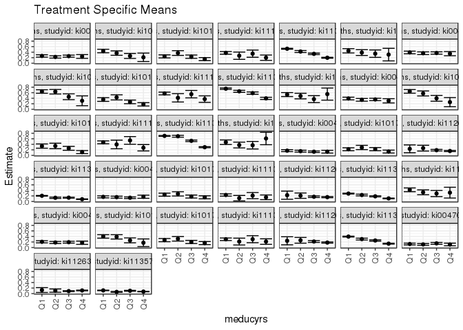

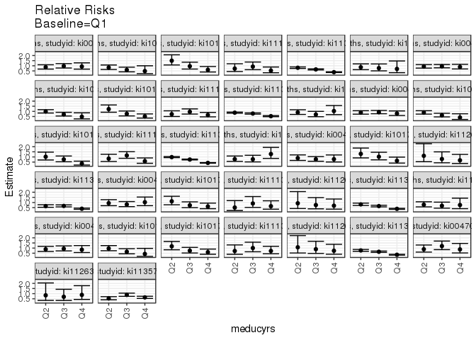

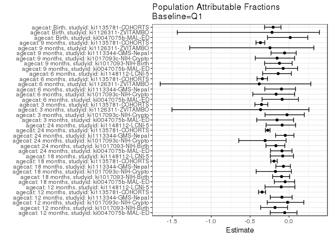

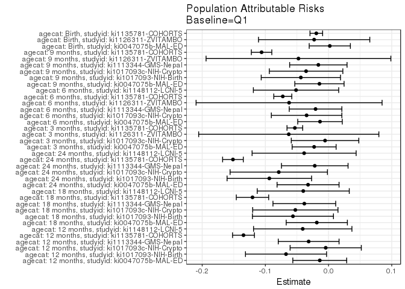

## Data Summary

| agecat | studyid | A | n | nA | nAY0 | nAY1 |
| --- | --- | --- | --- | --- | --- | --- |
| 12 months | ki0047075b-MAL-ED | Q1 | 1487 | 410 | 302 | 108 |
| 12 months | ki0047075b-MAL-ED | Q2 | 1487 | 400 | 309 | 91 |
| 12 months | ki0047075b-MAL-ED | Q3 | 1487 | 526 | 391 | 135 |
| 12 months | ki0047075b-MAL-ED | Q4 | 1487 | 151 | 114 | 37 |
| 12 months | ki1000108-CMC-V-BCS-2002 | Q1 | 368 | 106 | 47 | 59 |
| 12 months | ki1000108-CMC-V-BCS-2002 | Q2 | 368 | 196 | 98 | 98 |
| 12 months | ki1000108-CMC-V-BCS-2002 | Q3 | 368 | 57 | 33 | 24 |
| 12 months | ki1000108-CMC-V-BCS-2002 | Q4 | 368 | 9 | 7 | 2 |
| 12 months | ki1000108-IRC | Q1 | 406 | 181 | 123 | 58 |
| 12 months | ki1000108-IRC | Q2 | 406 | 102 | 70 | 32 |
| 12 months | ki1000108-IRC | Q3 | 406 | 112 | 85 | 27 |
| 12 months | ki1000108-IRC | Q4 | 406 | 11 | 9 | 2 |
| 12 months | ki1000109-EE | Q1 | 354 | 308 | 82 | 226 |
| 12 months | ki1000109-EE | Q2 | 354 | 32 | 13 | 19 |
| 12 months | ki1000109-EE | Q3 | 354 | 10 | 5 | 5 |
| 12 months | ki1000109-EE | Q4 | 354 | 4 | 2 | 2 |
| 12 months | ki1000304b-SAS-FoodSuppl | Q1 | 92 | 74 | 17 | 57 |
| 12 months | ki1000304b-SAS-FoodSuppl | Q2 | 92 | 11 | 1 | 10 |
| 12 months | ki1000304b-SAS-FoodSuppl | Q3 | 92 | 3 | 1 | 2 |
| 12 months | ki1000304b-SAS-FoodSuppl | Q4 | 92 | 4 | 0 | 4 |
| 12 months | ki1017093-NIH-Birth | Q1 | 491 | 233 | 130 | 103 |
| 12 months | ki1017093-NIH-Birth | Q2 | 491 | 139 | 88 | 51 |
| 12 months | ki1017093-NIH-Birth | Q3 | 491 | 91 | 67 | 24 |
| 12 months | ki1017093-NIH-Birth | Q4 | 491 | 28 | 22 | 6 |
| 12 months | ki1017093b-PROVIDE | Q1 | 153 | 73 | 48 | 25 |
| 12 months | ki1017093b-PROVIDE | Q2 | 153 | 57 | 41 | 16 |
| 12 months | ki1017093b-PROVIDE | Q3 | 153 | 20 | 18 | 2 |
| 12 months | ki1017093b-PROVIDE | Q4 | 153 | 3 | 2 | 1 |
| 12 months | ki1017093c-NIH-Crypto | Q1 | 706 | 227 | 171 | 56 |
| 12 months | ki1017093c-NIH-Crypto | Q2 | 706 | 122 | 77 | 45 |

[output cut: 362 more lines]

## Results Table

### Parameter: TSM

| agecat | studyid | intervention_level | baseline_level | estimate | ci_lower | ci_upper |
| --- | --- | --- | --- | --- | --- | --- |
| 12 months | ki0047075b-MAL-ED | Q1 | NA | 0.2634146 | 0.2207632 | 0.3060661 |
| 12 months | ki0047075b-MAL-ED | Q2 | NA | 0.2275000 | 0.1864036 | 0.2685964 |
| 12 months | ki0047075b-MAL-ED | Q3 | NA | 0.2566540 | 0.2193143 | 0.2939937 |
| 12 months | ki0047075b-MAL-ED | Q4 | NA | 0.2450331 | 0.1764082 | 0.3136581 |
| 12 months | ki1017093-NIH-Birth | Q1 | NA | 0.4420601 | 0.3782268 | 0.5058934 |
| 12 months | ki1017093-NIH-Birth | Q2 | NA | 0.3669065 | 0.2867027 | 0.4471103 |
| 12 months | ki1017093-NIH-Birth | Q3 | NA | 0.2637363 | 0.1731063 | 0.3543662 |
| 12 months | ki1017093-NIH-Birth | Q4 | NA | 0.2142857 | 0.0621467 | 0.3664248 |
| 12 months | ki1017093c-NIH-Crypto | Q1 | NA | 0.2466960 | 0.1905771 | 0.3028149 |
| 12 months | ki1017093c-NIH-Crypto | Q2 | NA | 0.3688525 | 0.2831748 | 0.4545302 |
| 12 months | ki1017093c-NIH-Crypto | Q3 | NA | 0.2368421 | 0.1763476 | 0.2973366 |
| 12 months | ki1017093c-NIH-Crypto | Q4 | NA | 0.1497006 | 0.0955510 | 0.2038502 |
| 12 months | ki1113344-GMS-Nepal | Q1 | NA | 0.3756345 | 0.3277722 | 0.4234968 |
| 12 months | ki1113344-GMS-Nepal | Q2 | NA | 0.2727273 | 0.1410150 | 0.4044396 |
| 12 months | ki1113344-GMS-Nepal | Q3 | NA | 0.3461538 | 0.2167312 | 0.4755765 |
| 12 months | ki1113344-GMS-Nepal | Q4 | NA | 0.2000000 | 0.1026708 | 0.2973292 |
| 12 months | ki1135781-COHORTS | Q1 | NA | 0.5238959 | 0.5068705 | 0.5409214 |
| 12 months | ki1135781-COHORTS | Q2 | NA | 0.4229137 | 0.3864959 | 0.4593316 |
| 12 months | ki1135781-COHORTS | Q3 | NA | 0.3390947 | 0.3124739 | 0.3657154 |
| 12 months | ki1135781-COHORTS | Q4 | NA | 0.1981265 | 0.1812181 | 0.2150349 |
| 12 months | ki1148112-LCNI-5 | Q1 | NA | 0.4493671 | 0.3716776 | 0.5270565 |
| 12 months | ki1148112-LCNI-5 | Q2 | NA | 0.3855422 | 0.2806600 | 0.4904244 |
| 12 months | ki1148112-LCNI-5 | Q3 | NA | 0.3469388 | 0.2134440 | 0.4804335 |
| 12 months | ki1148112-LCNI-5 | Q4 | NA | 0.3125000 | 0.0850111 | 0.5399889 |
| 18 months | ki0047075b-MAL-ED | Q1 | NA | 0.3897436 | 0.3413247 | 0.4381624 |
| 18 months | ki0047075b-MAL-ED | Q2 | NA | 0.3626667 | 0.3139898 | 0.4113435 |
| 18 months | ki0047075b-MAL-ED | Q3 | NA | 0.3702970 | 0.3281664 | 0.4124277 |
| 18 months | ki0047075b-MAL-ED | Q4 | NA | 0.3466667 | 0.2704800 | 0.4228533 |
| 18 months | ki1017093-NIH-Birth | Q1 | NA | 0.6438356 | 0.5803452 | 0.7073260 |
| 18 months | ki1017093-NIH-Birth | Q2 | NA | 0.6363636 | 0.5542119 | 0.7185154 |

[output cut: 118 more lines]

### Parameter: E(Y)

| agecat | studyid | intervention_level | baseline_level | estimate | ci_lower | ci_upper |
| --- | --- | --- | --- | --- | --- | --- |
| 12 months | ki0047075b-MAL-ED | NA | NA | 0.2494956 | 0.2487699 | 0.2502213 |
| 12 months | ki1017093-NIH-Birth | NA | NA | 0.3747454 | 0.3679329 | 0.3815579 |
| 12 months | ki1017093c-NIH-Crypto | NA | NA | 0.2422096 | 0.2370901 | 0.2473291 |
| 12 months | ki1113344-GMS-Nepal | NA | NA | 0.3441441 | 0.3391882 | 0.3491001 |
| 12 months | ki1135781-COHORTS | NA | NA | 0.3892435 | 0.3860737 | 0.3924133 |
| 12 months | ki1148112-LCNI-5 | NA | NA | 0.4084967 | 0.4033611 | 0.4136323 |
| 18 months | ki0047075b-MAL-ED | NA | NA | 0.3711268 | 0.3704335 | 0.3718200 |
| 18 months | ki1017093-NIH-Birth | NA | NA | 0.5874730 | 0.5783936 | 0.5965524 |
| 18 months | ki1017093c-NIH-Crypto | NA | NA | 0.3012618 | 0.2944684 | 0.3080552 |
| 18 months | ki1113344-GMS-Nepal | NA | NA | 0.5338208 | 0.5276891 | 0.5399526 |
| 18 months | ki1135781-COHORTS | NA | NA | 0.6248290 | 0.6201327 | 0.6295253 |
| 18 months | ki1148112-LCNI-5 | NA | NA | 0.4929178 | 0.4866778 | 0.4991579 |
| 24 months | ki0047075b-MAL-ED | NA | NA | 0.3570381 | 0.3557330 | 0.3583433 |
| 24 months | ki1017093-NIH-Birth | NA | NA | 0.5547786 | 0.5433701 | 0.5661870 |
| 24 months | ki1017093c-NIH-Crypto | NA | NA | 0.2568093 | 0.2490701 | 0.2645486 |
| 24 months | ki1113344-GMS-Nepal | NA | NA | 0.4495968 | 0.4434174 | 0.4557761 |
| 24 months | ki1135781-COHORTS | NA | NA | 0.5530102 | 0.5488888 | 0.5571316 |
| 24 months | ki1148112-LCNI-5 | NA | NA | 0.4368601 | 0.4291314 | 0.4445888 |
| 3 months | ki0047075b-MAL-ED | NA | NA | 0.1482611 | 0.1474817 | 0.1490406 |
| 3 months | ki1017093c-NIH-Crypto | NA | NA | 0.2142857 | 0.2107886 | 0.2177829 |
| 3 months | ki1126311-ZVITAMBO | NA | NA | 0.1723226 | 0.1713948 | 0.1732505 |
| 3 months | ki1135781-COHORTS | NA | NA | 0.1510135 | 0.1499103 | 0.1521168 |
| 6 months | ki0047075b-MAL-ED | NA | NA | 0.1523688 | 0.1516557 | 0.1530818 |
| 6 months | ki1017093c-NIH-Crypto | NA | NA | 0.2097902 | 0.2063302 | 0.2132502 |
| 6 months | ki1113344-GMS-Nepal | NA | NA | 0.2125000 | 0.2093592 | 0.2156408 |
| 6 months | ki1126311-ZVITAMBO | NA | NA | 0.1633350 | 0.1627555 | 0.1639144 |
| 6 months | ki1135781-COHORTS | NA | NA | 0.2117716 | 0.2101794 | 0.2133637 |
| 6 months | ki1148112-LCNI-5 | NA | NA | 0.3688119 | 0.3634785 | 0.3741453 |
| 9 months | ki0047075b-MAL-ED | NA | NA | 0.1913907 | 0.1908449 | 0.1919365 |
| 9 months | ki1017093-NIH-Birth | NA | NA | 0.3570020 | 0.3509190 | 0.3630850 |
| 9 months | ki1017093c-NIH-Crypto | NA | NA | 0.2322946 | 0.2281923 | 0.2363970 |
| 9 months | ki1113344-GMS-Nepal | NA | NA | 0.2823315 | 0.2795556 | 0.2851074 |
| 9 months | ki1126311-ZVITAMBO | NA | NA | 0.1947986 | 0.1938196 | 0.1957775 |
| 9 months | ki1135781-COHORTS | NA | NA | 0.2889479 | 0.2865466 | 0.2913492 |
| Birth | ki0047075b-MAL-ED | NA | NA | 0.1275986 | 0.1267313 | 0.1284658 |
| Birth | ki1126311-ZVITAMBO | NA | NA | 0.1044689 | 0.1040938 | 0.1048441 |
| Birth | ki1135781-COHORTS | NA | NA | 0.0949579 | 0.0945211 | 0.0953946 |

### Parameter: RR

| agecat | studyid | intervention_level | baseline_level | estimate | ci_lower | ci_upper |
| --- | --- | --- | --- | --- | --- | --- |
| 12 months | ki0047075b-MAL-ED | Q2 | Q1 | 0.8636574 | 0.6776204 | 1.1007699 |
| 12 months | ki0047075b-MAL-ED | Q3 | Q1 | 0.9743346 | 0.7837397 | 1.2112795 |
| 12 months | ki0047075b-MAL-ED | Q4 | Q1 | 0.9302183 | 0.6731162 | 1.2855226 |
| 12 months | ki1017093-NIH-Birth | Q2 | Q1 | 0.8299923 | 0.6386994 | 1.0785783 |
| 12 months | ki1017093-NIH-Birth | Q3 | Q1 | 0.5966073 | 0.4109676 | 0.8661030 |
| 12 months | ki1017093-NIH-Birth | Q4 | Q1 | 0.4847434 | 0.2348864 | 1.0003823 |
| 12 months | ki1017093c-NIH-Crypto | Q2 | Q1 | 1.4951698 | 1.0801717 | 2.0696086 |
| 12 months | ki1017093c-NIH-Crypto | Q3 | Q1 | 0.9600564 | 0.6819504 | 1.3515767 |
| 12 months | ki1017093c-NIH-Crypto | Q4 | Q1 | 0.6068221 | 0.3958088 | 0.9303305 |
| 12 months | ki1113344-GMS-Nepal | Q2 | Q1 | 0.7260442 | 0.4406012 | 1.1964113 |
| 12 months | ki1113344-GMS-Nepal | Q3 | Q1 | 0.9215177 | 0.6208063 | 1.3678901 |
| 12 months | ki1113344-GMS-Nepal | Q4 | Q1 | 0.5324324 | 0.3219531 | 0.8805142 |
| 12 months | ki1135781-COHORTS | Q2 | Q1 | 0.8072476 | 0.7362653 | 0.8850731 |
| 12 months | ki1135781-COHORTS | Q3 | Q1 | 0.6472557 | 0.5945327 | 0.7046542 |
| 12 months | ki1135781-COHORTS | Q4 | Q1 | 0.3781790 | 0.3451738 | 0.4143402 |
| 12 months | ki1148112-LCNI-5 | Q2 | Q1 | 0.8579671 | 0.6215641 | 1.1842825 |
| 12 months | ki1148112-LCNI-5 | Q3 | Q1 | 0.7720609 | 0.5063503 | 1.1772050 |
| 12 months | ki1148112-LCNI-5 | Q4 | Q1 | 0.6954225 | 0.3290820 | 1.4695804 |
| 18 months | ki0047075b-MAL-ED | Q2 | Q1 | 0.9305263 | 0.7749984 | 1.1172659 |
| 18 months | ki0047075b-MAL-ED | Q3 | Q1 | 0.9501042 | 0.8028054 | 1.1244295 |
| 18 months | ki0047075b-MAL-ED | Q4 | Q1 | 0.8894737 | 0.6910260 | 1.1449112 |
| 18 months | ki1017093-NIH-Birth | Q2 | Q1 | 0.9883946 | 0.8401929 | 1.1627376 |
| 18 months | ki1017093-NIH-Birth | Q3 | Q1 | 0.7043543 | 0.5472735 | 0.9065210 |
| 18 months | ki1017093-NIH-Birth | Q4 | Q1 | 0.4779051 | 0.2660952 | 0.8583140 |
| 18 months | ki1017093c-NIH-Crypto | Q2 | Q1 | 1.2185880 | 0.9142060 | 1.6243129 |
| 18 months | ki1017093c-NIH-Crypto | Q3 | Q1 | 0.7590062 | 0.5568644 | 1.0345255 |
| 18 months | ki1017093c-NIH-Crypto | Q4 | Q1 | 0.5105189 | 0.3472052 | 0.7506500 |
| 18 months | ki1113344-GMS-Nepal | Q2 | Q1 | 0.7246759 | 0.4985223 | 1.0534237 |
| 18 months | ki1113344-GMS-Nepal | Q3 | Q1 | 0.9563148 | 0.7374952 | 1.2400596 |
| 18 months | ki1113344-GMS-Nepal | Q4 | Q1 | 0.6453222 | 0.4641745 | 0.8971642 |

[output cut: 81 more lines]

### Parameter: PAR

| agecat | studyid | intervention_level | baseline_level | estimate | ci_lower | ci_upper |
| --- | --- | --- | --- | --- | --- | --- |
| 12 months | ki0047075b-MAL-ED | Q1 | NA | -0.0139190 | -0.0565766 | 0.0287386 |
| 12 months | ki1017093-NIH-Birth | Q1 | NA | -0.0673147 | -0.1315104 | -0.0031189 |
| 12 months | ki1017093c-NIH-Crypto | Q1 | NA | -0.0044864 | -0.0608383 | 0.0518655 |
| 12 months | ki1113344-GMS-Nepal | Q1 | NA | -0.0314904 | -0.0796086 | 0.0166278 |
| 12 months | ki1135781-COHORTS | Q1 | NA | -0.1346524 | -0.1519705 | -0.1173344 |
| 12 months | ki1148112-LCNI-5 | Q1 | NA | -0.0408704 | -0.1187294 | 0.0369887 |
| 18 months | ki0047075b-MAL-ED | Q1 | NA | -0.0186168 | -0.0670406 | 0.0298070 |
| 18 months | ki1017093-NIH-Birth | Q1 | NA | -0.0563626 | -0.1204990 | 0.0077737 |
| 18 months | ki1017093c-NIH-Crypto | Q1 | NA | -0.0525843 | -0.1200929 | 0.0149242 |
| 18 months | ki1113344-GMS-Nepal | Q1 | NA | -0.0383441 | -0.0879994 | 0.0113111 |
| 18 months | ki1135781-COHORTS | Q1 | NA | -0.1203884 | -0.1460108 | -0.0947660 |
| 18 months | ki1148112-LCNI-5 | Q1 | NA | -0.0400492 | -0.1129028 | 0.0328045 |
| 24 months | ki0047075b-MAL-ED | Q1 | NA | -0.0324356 | -0.0814993 | 0.0166282 |
| 24 months | ki1017093-NIH-Birth | Q1 | NA | -0.0937363 | -0.1606325 | -0.0268401 |
| 24 months | ki1017093c-NIH-Crypto | Q1 | NA | -0.0788071 | -0.1558667 | -0.0017475 |
| 24 months | ki1113344-GMS-Nepal | Q1 | NA | -0.0218318 | -0.0745447 | 0.0308811 |
| 24 months | ki1135781-COHORTS | Q1 | NA | -0.1513213 | -0.1676954 | -0.1349471 |
| 24 months | ki1148112-LCNI-5 | Q1 | NA | -0.0386644 | -0.1210199 | 0.0436911 |
| 3 months | ki0047075b-MAL-ED | Q1 | NA | -0.0228500 | -0.0576653 | 0.0119654 |
| 3 months | ki1017093c-NIH-Crypto | Q1 | NA | -0.0055419 | -0.0589824 | 0.0478987 |
| 3 months | ki1126311-ZVITAMBO | Q1 | NA | -0.0629715 | -0.2055869 | 0.0796438 |
| 3 months | ki1135781-COHORTS | Q1 | NA | -0.0533482 | -0.0657695 | -0.0409269 |
| 6 months | ki0047075b-MAL-ED | Q1 | NA | -0.0135191 | -0.0487784 | 0.0217402 |
| 6 months | ki1017093c-NIH-Crypto | Q1 | NA | -0.0347513 | -0.0905664 | 0.0210639 |
| 6 months | ki1113344-GMS-Nepal | Q1 | NA | -0.0205827 | -0.0622234 | 0.0210580 |
| 6 months | ki1126311-ZVITAMBO | Q1 | NA | -0.0624715 | -0.2096924 | 0.0847494 |
| 6 months | ki1135781-COHORTS | Q1 | NA | -0.0724444 | -0.0866739 | -0.0582148 |
| 6 months | ki1148112-LCNI-5 | Q1 | NA | -0.0514780 | -0.1190146 | 0.0160587 |
| 9 months | ki0047075b-MAL-ED | Q1 | NA | -0.0144204 | -0.0534286 | 0.0245878 |
| 9 months | ki1017093-NIH-Birth | Q1 | NA | -0.0438419 | -0.1065915 | 0.0189076 |
| 9 months | ki1017093c-NIH-Crypto | Q1 | NA | -0.0355625 | -0.0937412 | 0.0226161 |
| 9 months | ki1113344-GMS-Nepal | Q1 | NA | -0.0161379 | -0.0615620 | 0.0292863 |
| 9 months | ki1126311-ZVITAMBO | Q1 | NA | -0.0476257 | -0.1938813 | 0.0986300 |
| 9 months | ki1135781-COHORTS | Q1 | NA | -0.1060242 | -0.1222174 | -0.0898309 |
| Birth | ki0047075b-MAL-ED | Q1 | NA | 0.0019704 | -0.0306138 | 0.0345547 |
| Birth | ki1126311-ZVITAMBO | Q1 | NA | -0.0228038 | -0.1108966 | 0.0652891 |
| Birth | ki1135781-COHORTS | Q1 | NA | -0.0193718 | -0.0293675 | -0.0093760 |

### Parameter: PAF

| agecat | studyid | intervention_level | baseline_level | estimate | ci_lower | ci_upper |
| --- | --- | --- | --- | --- | --- | --- |
| 12 months | ki0047075b-MAL-ED | Q1 | NA | -0.0557886 | -0.2413898 | 0.1020633 |
| 12 months | ki1017093-NIH-Birth | Q1 | NA | -0.1796277 | -0.3644321 | -0.0198540 |
| 12 months | ki1017093c-NIH-Crypto | Q1 | NA | -0.0185228 | -0.2799425 | 0.1895037 |
| 12 months | ki1113344-GMS-Nepal | Q1 | NA | -0.0915034 | -0.2408350 | 0.0398564 |
| 12 months | ki1135781-COHORTS | Q1 | NA | -0.3459337 | -0.3917898 | -0.3015883 |
| 12 months | ki1148112-LCNI-5 | Q1 | NA | -0.1000506 | -0.3082614 | 0.0750233 |
| 18 months | ki0047075b-MAL-ED | Q1 | NA | -0.0501630 | -0.1890944 | 0.0725359 |
| 18 months | ki1017093-NIH-Birth | Q1 | NA | -0.0959408 | -0.2109797 | 0.0081698 |
| 18 months | ki1017093c-NIH-Crypto | Q1 | NA | -0.1745469 | -0.4219567 | 0.0298154 |
| 18 months | ki1113344-GMS-Nepal | Q1 | NA | -0.0718295 | -0.1691188 | 0.0173637 |
| 18 months | ki1135781-COHORTS | Q1 | NA | -0.1926741 | -0.2346945 | -0.1520839 |
| 18 months | ki1148112-LCNI-5 | Q1 | NA | -0.0812492 | -0.2397333 | 0.0569747 |
| 24 months | ki0047075b-MAL-ED | Q1 | NA | -0.0908462 | -0.2373062 | 0.0382773 |
| 24 months | ki1017093-NIH-Birth | Q1 | NA | -0.1689616 | -0.2966929 | -0.0538126 |
| 24 months | ki1017093c-NIH-Crypto | Q1 | NA | -0.3068701 | -0.6455252 | -0.0379114 |
| 24 months | ki1113344-GMS-Nepal | Q1 | NA | -0.0485586 | -0.1726992 | 0.0624406 |
| 24 months | ki1135781-COHORTS | Q1 | NA | -0.2736319 | -0.3041796 | -0.2437998 |
| 24 months | ki1148112-LCNI-5 | Q1 | NA | -0.0885052 | -0.2945136 | 0.0847190 |
| 3 months | ki0047075b-MAL-ED | Q1 | NA | -0.1541198 | -0.4145637 | 0.0583722 |
| 3 months | ki1017093c-NIH-Crypto | Q1 | NA | -0.0258621 | -0.3082138 | 0.1955497 |
| 3 months | ki1126311-ZVITAMBO | Q1 | NA | -0.3654280 | -1.5032611 | 0.2552141 |
| 3 months | ki1135781-COHORTS | Q1 | NA | -0.3532675 | -0.4383576 | -0.2732111 |
| 6 months | ki0047075b-MAL-ED | Q1 | NA | -0.0887261 | -0.3465764 | 0.1197494 |
| 6 months | ki1017093c-NIH-Crypto | Q1 | NA | -0.1656477 | -0.4647407 | 0.0723719 |
| 6 months | ki1113344-GMS-Nepal | Q1 | NA | -0.0968598 | -0.3115460 | 0.0826845 |
| 6 months | ki1126311-ZVITAMBO | Q1 | NA | -0.3824747 | -1.6534429 | 0.2797145 |
| 6 months | ki1135781-COHORTS | Q1 | NA | -0.3420872 | -0.4113441 | -0.2762289 |
| 6 months | ki1148112-LCNI-5 | Q1 | NA | -0.1395779 | -0.3384311 | 0.0297314 |
| 9 months | ki0047075b-MAL-ED | Q1 | NA | -0.0753454 | -0.2997588 | 0.1103213 |
| 9 months | ki1017093-NIH-Birth | Q1 | NA | -0.1228058 | -0.3133301 | 0.0400792 |
| 9 months | ki1017093c-NIH-Crypto | Q1 | NA | -0.1530923 | -0.4330794 | 0.0721924 |
| 9 months | ki1113344-GMS-Nepal | Q1 | NA | -0.0571593 | -0.2309781 | 0.0921156 |
| 9 months | ki1126311-ZVITAMBO | Q1 | NA | -0.2444868 | -1.2751254 | 0.3192695 |
| 9 months | ki1135781-COHORTS | Q1 | NA | -0.3669318 | -0.4246935 | -0.3115119 |
| Birth | ki0047075b-MAL-ED | Q1 | NA | 0.0154424 | -0.2760954 | 0.2403752 |
| Birth | ki1126311-ZVITAMBO | Q1 | NA | -0.2182828 | -1.4341643 | 0.3902577 |
| Birth | ki1135781-COHORTS | Q1 | NA | -0.2040038 | -0.3140570 | -0.1031677 |